# Polinomial y SVR

Saul Mercado Pedroza

17/02/2024

# Polinomial

La regresión polinomial es un caso especial de regresió lineal, ya que es muy parecida a esta, sin embargo, la diferencia radica en que los datos acá no son lineales, por lo que se deben de implementar polinomios de n para obtener el modelo > Grado del polinomio Para determinar el grado del polinomio fué necesario la elaboración de una función que constara con un ciclo, el cual, haría el cálculo del **AIC**.

```r
polyn <- function() {
for (i in c(1:10)) {
    mdl.Poly <- lm(formula = Profit ~ poly(R.D.Spend, i), data = df.Startup.Train)
    print(paste("Modelo ", i))
    aic <- AIC(mdl.Poly)
    print(aic)
}
}
```

Y entregando el siguiente resultado, de los cuales se seleccióna los de menor valor

```
## [1] "Modelo  1"
```

```
## [1] 854.343
```

```
## [1] "Modelo  2"
```

```
## [1] 855.9478
```

```
## [1] "Modelo  3"
```

```
## [1] 850.857
```

```
## [1] "Modelo  4"
```

```
## [1] 851.4186
```

```
## [1] "Modelo  5"
```

```
## [1] 852.3052
```

```
## [1] "Modelo  6"
```

```
## [1] 851.0129
```

```
## [1] "Modelo  7"
```

```
## [1] 850.7029
```

```
## [1] "Modelo  8"
```

```
## [1] 851.5291
```

```
## [1] "Modelo  9"
```

```
## [1] 839.0783
```

```
## [1] "Modelo  10"
```

```
## [1] 840.3691
```

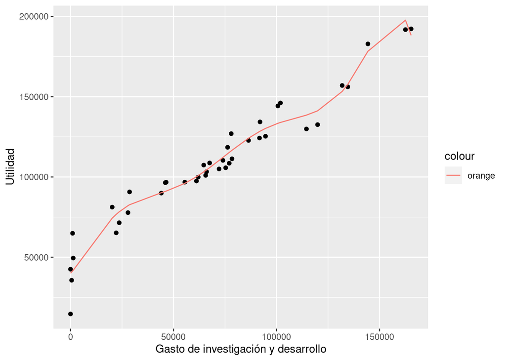

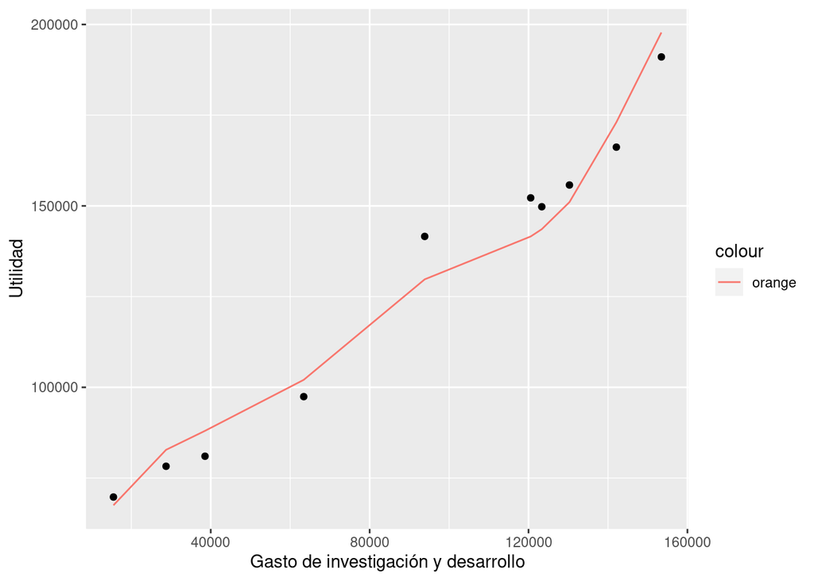

# SVR

SVR es uno de los principales exponentes de la aplicación de la optimización de la matemática al parendizaje supervisado, teniendo como objetivo realizar la predicción a partir de un problema de optimización geométrica con restricciones lineales.

```r
svr.lin <- svm(formula = Profit ~ ., data = df.Startup.Train, kernel = "line", scale = F)
summary(svr.lin)
```

```
##
## Call:
## svm(formula = Profit ~ ., data = df.Startup.Train, kernel = "line",
##     scale = F)
##
##
## Parameters:
##    SVM-Type:  eps-regression
##  SVM-Kernel:  linear
##        cost:  1
##       gamma:  0.25
##     epsilon:  0.1
##
##
## Number of Support Vectors:  35
```

```r
svr.poly <- svm(formula = Profit ~ ., data = df.Startup.Train, kernel = "polynomial", scale = F)
summary(svr.poly)
```

```
##
## Call:
## svm(formula = Profit ~ ., data = df.Startup.Train, kernel = "polynomial",
##     scale = F)
##
##
## Parameters:
##    SVM-Type:  eps-regression
##  SVM-Kernel:  polynomial
##        cost:  1
##      degree:  3
##       gamma:  0.25
##      coef.0:  0
##     epsilon:  0.1
##
##
## Number of Support Vectors:  27
```

```r
svr.rad <- svm(formula = Profit ~ ., data = df.Startup.Train, kernel = "radial", scale = F)
summary(svr.rad)
```

```
##
## Call:
## svm(formula = Profit ~ ., data = df.Startup.Train, kernel = "radial",
##     scale = F)
##
##
## Parameters:
##    SVM-Type:  eps-regression
##  SVM-Kernel:  radial
##        cost:  1
##       gamma:  0.25
##     epsilon:  0.1
##
##
## Number of Support Vectors:  40
```

```r
svr.sig <- svm(formula = Profit ~ ., data = df.Startup.Train, kernel = "sigmoid", scale = F)
summary(svr.sig)
```

```
##
## Call:
## svm(formula = Profit ~ ., data = df.Startup.Train, kernel = "sigmoid",
##     scale = F)
##
##
## Parameters:
##    SVM-Type:  eps-regression
##  SVM-Kernel:  sigmoid
##        cost:  1
##       gamma:  0.25
##      coef.0:  0
##     epsilon:  0.1
##
##
## Number of Support Vectors:  40
```

Encontrando como mejor modelo el **svr.lin** y graficando por último este modelo

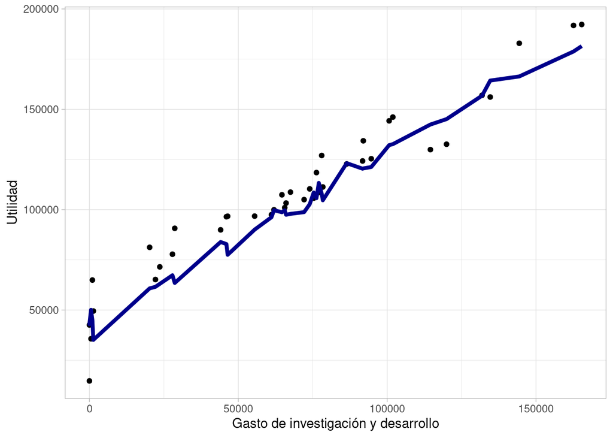

> **Conclusión**: Esta actividad funcionó para conocer el como dependiendo del dataset con el que cuentes y las técnicas que utilices influyen en el mejor modelo para poder trabajar con los datos, resultando ser mejor en mi caso el polinomial, ya que logré que se ajustara mejor a los datos con los cuales se trabajó

## Enlaces de referencia

[1] Regresión Polinomial – Teoría, [link] (https://aprendeia.com/algoritmo-regresion-polinomial-machine-learning/)

[2] Regresión lineal simple y polinomial: teoría y práctica, [link] (https://www.ccg.unam.mx/~vinuesa/R4biosciences/docs/Tema9_regresion.html)

[3] Support vector regression : propiedades y aplicaciones, [link] (https://idus.us.es/handle/11441/43808)

[4] ¿Qué es el criterio de información Akaike AIC?, [link] (https://keepcoding.io/blog/que-es-el-criterio-de-informacion-akaike/)